# PSTAT 122: Final Project

Sylvia Li

2025-03-06

# Introduction

A core aspect of experiments across all fields is designing an experiment that can accurately reveal the affect of one variable, outside of the influence of others. A key part of this is how questions or instructions are presented, since how they are worded has the potential of affecting how a participant might respond. This is known as question-wording bias.

Research has shown that differences in phrasing can lead to variations in how people interpret and respond to questions, influencing the conclusions drawn from a study. Rugg and Cantril (1944) demonstrated that the context of questions can affect answers to opinion questions. This was seen with deviations from “objective” wording and they provide examples showing that sizeable question effects can occur in areas where opinions are widely varied.

For example, specific framing in questions can lead participants to answer in a way that aligns with social norms rather than their true beliefs. “Psychologists have worried about the distortions introduced into standardized personality measures by social desirability bias. Survey researchers have had similar concerns about the accuracy of survey reports about such topics as illicit drug use, abortion, and sexual behavior,” (Tourangeau & Yan, 2007). Thus the design of surveys and experiments is crucial in making sure results of these studies are accurate.

This is particularly relevant in discussions about environmental issues, where framing can drastically impact public perception and policy support. “In public discourse and survey research, global climate change is sometimes referred to as”global warming” and sometimes as “climate change.” An analysis of web sites of conservative and liberal think tanks suggests that conservatives prefer to use the term “global warming” whereas liberals prefer “climate change.” A question wording experiment (N = 2267) illustrates the power of these frames: Republicans were less likely to endorse that the phenomenon is real when it was referred to as “global warming” (44.0%) rather than “climate change” (60.2%), whereas Democrats were unaffected by question wording (86.9% vs. 86.4%). As a result, the partisan divide on the issue dropped from 42.9 percentage points under a “global warming” frame to 26.2 percentage points under a “climate change” frame,” (Schuldt, Konrath, & Schwarz, 2011).

In this experiment, we aimed to answer the question “Does the wording of a survey question influence how concerned a student is about a local environmental topic?”. For this project, the topic of cliff erosion and property damage on DP in Isla Vista was used as the local environmental issue for UCSB students. Three alternate wordings of the topic were used as treatment groups and are listed as follows:

1. I am worried about cliff erosion in Isla Vista.
2. I am worried about houses and decks on DP falling into the ocean.
3. I am worried about climate change and cliff erosion causing houses and decks on DP to fall into the ocean.

In the case of cliff erosion in Isla Vista, how the problem is presented, whether as a structural and safety issue, an immediate risk to property, or as part of the broader context of climate change, may influence how much concern students express. The statements were formulated with intention to influence what the particpant was thinking about when answering the question. 1) focused solely on the environmental and physical process of cliff erosion in Isla Vista. 2) focused mainly on the personal affects that may be felt by UCSB students, who may spend time on or near houses/decks on DP in Isla Vista. 3) was a combination of the first two, tying in climate change and cliff erosion as physical processes and the personal stakes of property damage and possible injury. Treatment 3 also incorporated a direct cause and effect statement.

# Methods

The treatment groups for this experiment were the versions of the statement shown in the survey.

Below is how the survey questions appeared for participants.

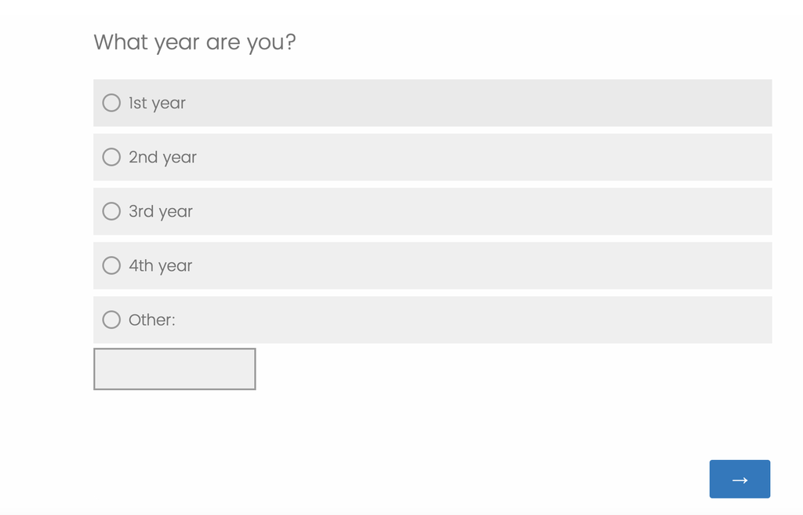

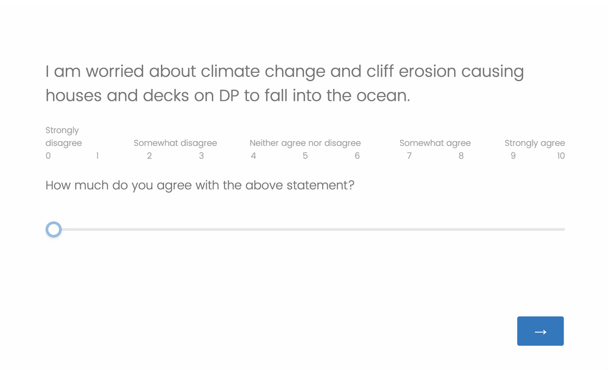

The data for this experiment was collected through a random anonymous survey on qualtrics, which randomized which version of the statement was shown to the participant. The number of times each statement was shown was kept equal by the website. The survey was distributed through a personal account’s public story. 74 survey responses were obtained and below is a sample of one response.

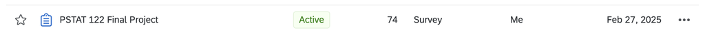

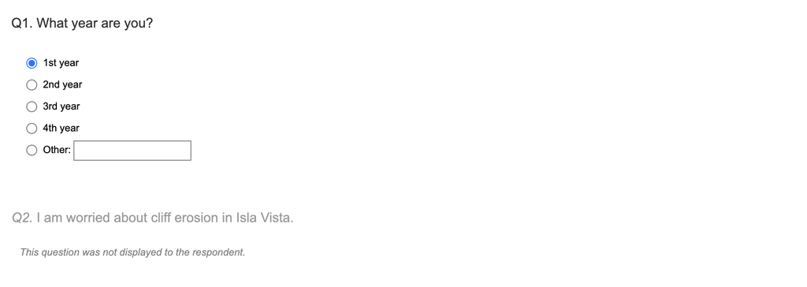

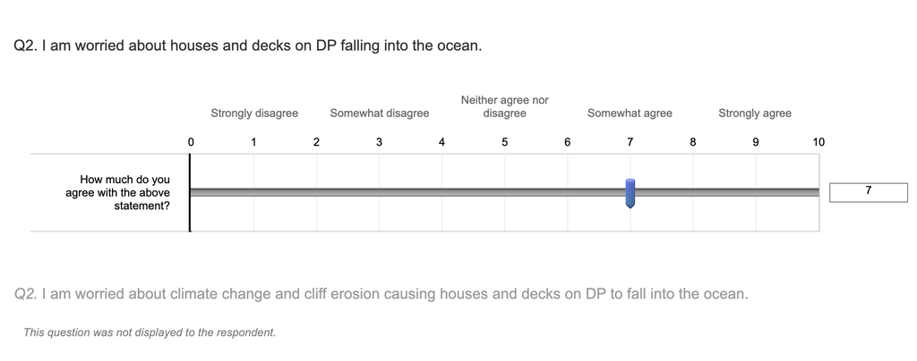

This experiment was a Generalized Complete Block Design (GCBD), since the same treatment could be repeated multiple times within each block. Thus, an ANOVA parametric test should be performed on the data, since there is one primary factor of interest and no interaction terms.

To check that this model is the right fit, we should confirm that the data is normal, there is no structure to the data, and that there are equal variances. In this case, the data may contain some outliers or may be skewed if many people are in fact worried about cliff erosion. The other assumptions should be met, excluding outliers. If these assumptions are not met, a permutation test may be better suited for the data.

A technical difficulty in collecting the data was the proportion of participants in each block.

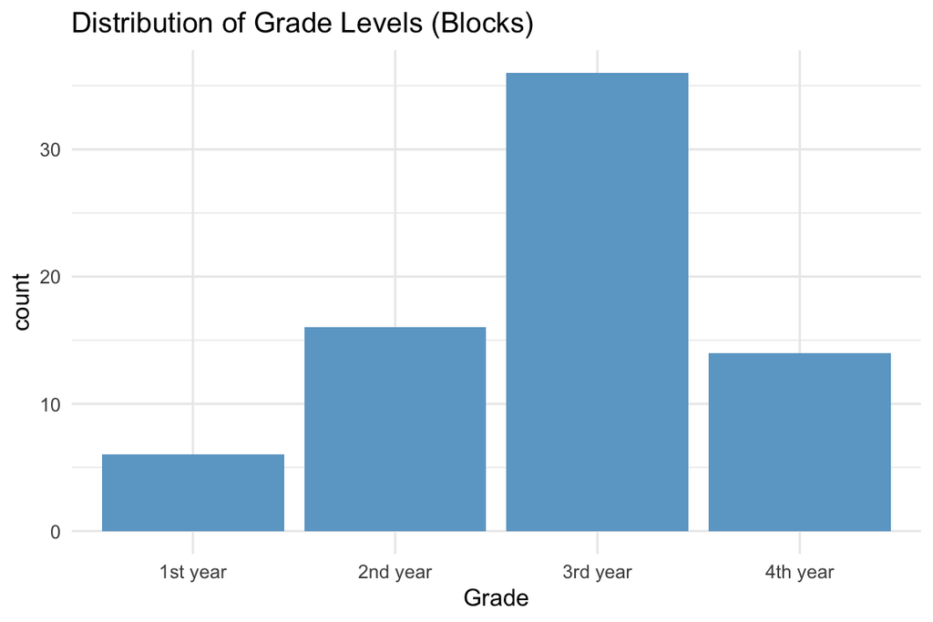

```r
ggplot(survey_data, aes(x=Grade)) + geom_bar(fill='skyblue3') +
  theme_minimal() + labs(title = "Distribution of Grade Levels (Blocks)")
```

Since the survey was posted to a personal Instagram account of a 3rd year, a majority of responses and those who viewed the story were also 3rd years. This may affect the statistical significance of the experiment on each block and the affect of the blocks in the full model.

Additionally, two survey responses were cleaned from the dataset; one did not have a rating on how much they agreed with the statement, and one answered the grade level question with Other: (no filled in response). While the Other category could have been a separate block in the experiment, only one survey with this block was received, making it impossible to test all of the treatments on that block. Thus the response was removed from the dataset instead.

# Results

A preview of the collected dataset is as follows.

```r
kable(head(survey_data), caption = 'Survey Results Preview')
```

Survey Results Preview

| Grade | Treatment | Score |
| --- | --- | --- |
| 3rd year | 2 | 7 |
| 4th year | 1 | 6 |
| 1st year | 3 | 9 |
| 4th year | 1 | 10 |
| 2nd year | 3 | 10 |
| 3rd year | 2 | 7 |

The summary statistics of the dataset are displayed in the following table and visual representations of the data are shown in the following graphs.

```r
summary_table <- survey_data %>%
  group_by(Treatment) %>%
  summarize(
    Mean = round(mean(Score), 2),
    `Standard Deviation` = round(sd(Score), 2),
    Variance = round(var(Score), 2),
    `Sample Size` = n()
  )

kable(summary_table, caption = "Summary Statistics by Treatment")
```

Summary Statistics by Treatment

| Treatment | Mean | Standard Deviation | Variance | Sample Size |
| --- | --- | --- | --- | --- |
| 1 | 7.54 | 1.61 | 2.61 | 24 |
| 2 | 6.76 | 2.05 | 4.19 | 25 |
| 3 | 8.09 | 1.44 | 2.08 | 23 |

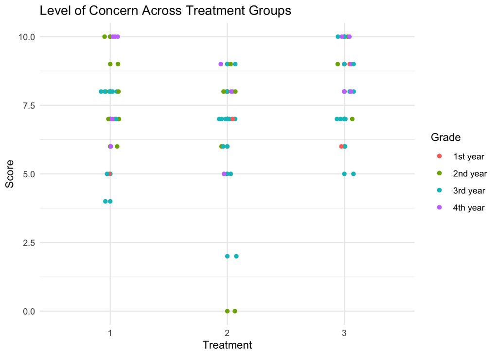

```r
ggplot(data=survey_data, aes(y=Score, x=Treatment, group = Grade, color = Grade)) +
geom_point() + geom_jitter(width=0.08, height=0) +
ggtitle("Level of Concern Across Treatment Groups") +
ylab('Score') + theme_minimal()
```

From this scatterplot, it looks like there could be a difference in the mean and distribution of scores across different treatment groups. Treatment 2 looks like it may have a few outliers compared to the rest of the data.

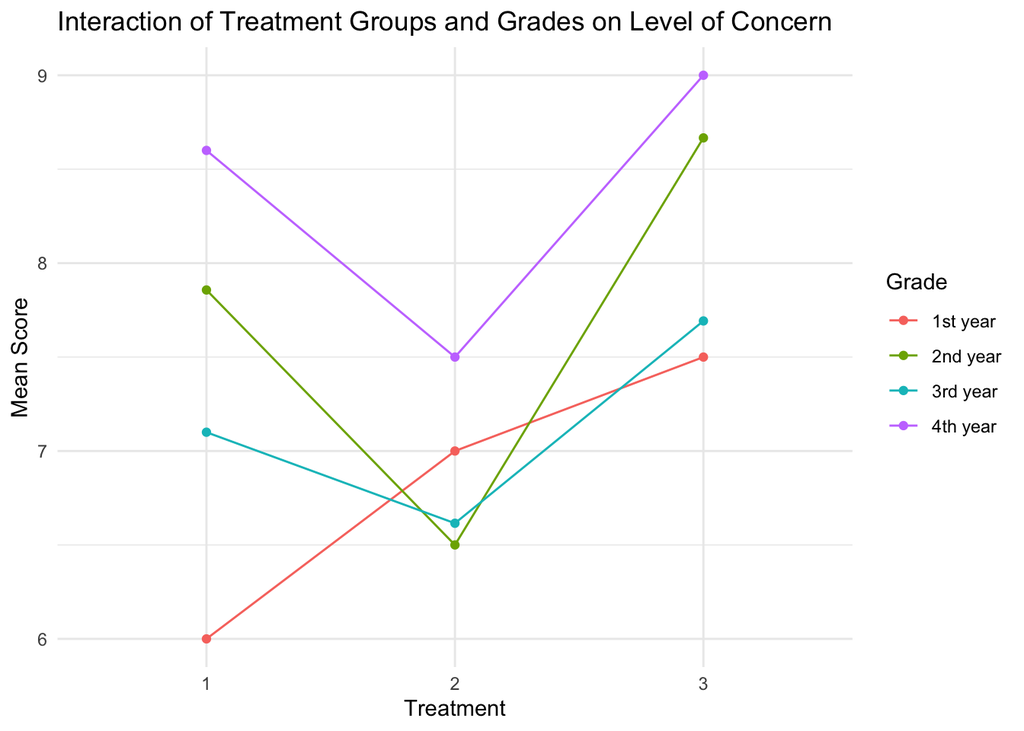

```r
ggplot(data=means, aes(y=mean, x=Treatment,
group=Grade, color=Grade)) +
geom_point() + geom_line() +
ggtitle("Interaction of Treatment Groups and Grades on Level of Concern") +
ylab("Mean Score") + theme_minimal()
```

This interaction plot reveals how for all almost all blocks (beside 1st years), the average score and level of concern was lower for Treatment 2 compared to Treatment 1, and higher for Treatment 3. The 1st year block was the smallest, with only 6 observations, possibly affecting this result.

## GCBD ANOVA Test

The following ANOVA test was performed on the data.

$H_0 : \mu_1 = \mu_2 = \mu_3$ Where each $\mu$ corresponds to the mean of a treatment group

$H_A$ : at least one mean is different

```r
model1 <- aov(Score ~ Treatment + Grade, data= survey_data)
anova_summary <- summary(model1)
anova_table <- anova_summary[[1]]
anova_matrix <- matrix(c(
  anova_table[1, "Df"], anova_table[1, "Sum Sq"], anova_table[1, "Mean Sq"], anova_table[1, "F value"], anova_table[1, "Pr(>F)"],
  anova_table[2, "Df"], anova_table[2, "Sum Sq"], anova_table[2, "Mean Sq"], anova_table[2, "F value"], anova_table[2, "Pr(>F)"],
  anova_table[3, "Df"], anova_table[3, "Sum Sq"], anova_table[3, "Mean Sq"], NA, NA),
nrow = 3, byrow = TRUE)
anova_matrix <- matrix(as.character(signif(anova_matrix, 4)), nrow=3)
colnames(anova_matrix) <- c("Df", "Sum Sq", "Mean Sq", "F value", "p-value")
rownames(anova_matrix) <- c("Treatment", "Block", "Residuals")

kable(anova_matrix, caption = "ANOVA Results")
```

ANOVA Results

|  | Df | Sum Sq | Mean Sq | F value | p-value |
| --- | --- | --- | --- | --- | --- |
| Treatment | 2 | 21.43 | 10.72 | 3.759 | 0.02844 |
| Block | 3 | 18.19 | 6.063 | 2.127 | 0.1052 |
| Residuals | 66 | 188.2 | 2.851 | NA | NA |

The p - value for the Treatments is 0.02844. At an $\alpha$ = 0.05 level, we reject $H_0$ that there are no differences between the mean scores of the treatment groups. The p-value for the blocks (0.1052) reflects that the variation between blocks is not statistically significant on the mean scores, since the block p-value is greater than $\alpha$ = 0.05.

Using Tukey’s test, we can determine which treatment pairwise comparisons are statistically significant in the model.

```r
hsd_output <- TukeyHSD(model1)
kable(hsd_output$Treatment, caption = 'Pairwise Comparisons')
```

Pairwise Comparisons

|  | diff | lwr | upr | p adj |
| --- | --- | --- | --- | --- |
| 2-1 | -0.7816667 | -1.9385907 | 0.3752574 | 0.2444533 |
| 3-1 | 0.5452899 | -0.6360146 | 1.7265943 | 0.5133305 |
| 3-2 | 1.3269565 | 0.1572709 | 2.4966421 | 0.0224017 |

It seems that only the difference in means between Treatments 2 and 3 are statistically significant to the model.

## Model Checking

In order to verify that the results of the ANOVA test are accurate and reliable, model checking should be performed. As mentioned above, we should confirm that the data is normal, there is no structure to the data, and that there are equal variances.

### Normality:

Shapiro Wilk Normality Test

|  | Data | TestStatistic | pvalue |
| --- | --- | --- | --- |
| W | model1$residuals | 0.8964277 | 2.21e-05 |

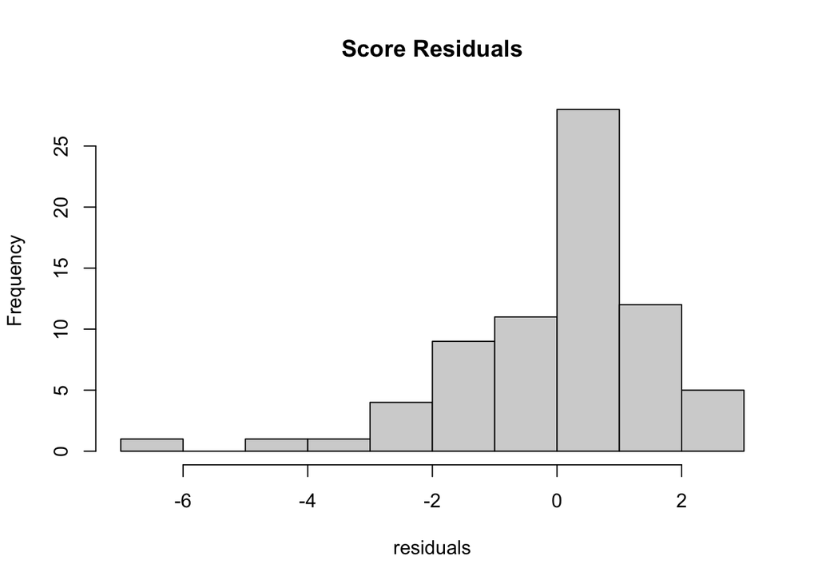

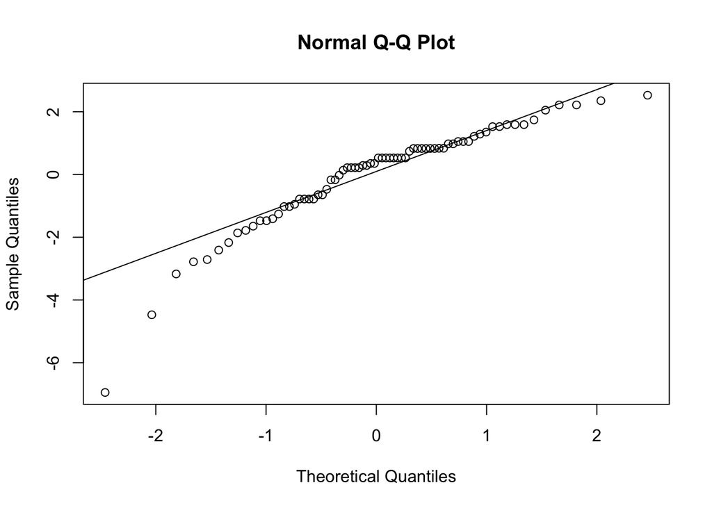

```r
hist(model1$residuals, xlab="residuals", main="Score Residuals")
qqnorm(model1$residuals)
qqline(model1$residuals)
shapiro <- shapiro.test(model1$residuals)

shapirotable <-
data.frame(
  Data = c('model1$residuals'),
  TestStatistic = c(shapiro$statistic),
  pvalue = c(shapiro$p.value)
)
kable(shapirotable, caption="Shapiro Wilk Normality Test")
```

The visual representations show that this data may be skewed and not quite normal. According to the Shapiro-Wilk test, the p-value is less than 0.05, thus rejecting the null hypothesis that the data is normal. This data does not meet the normality assumption.

### Structure to Data:

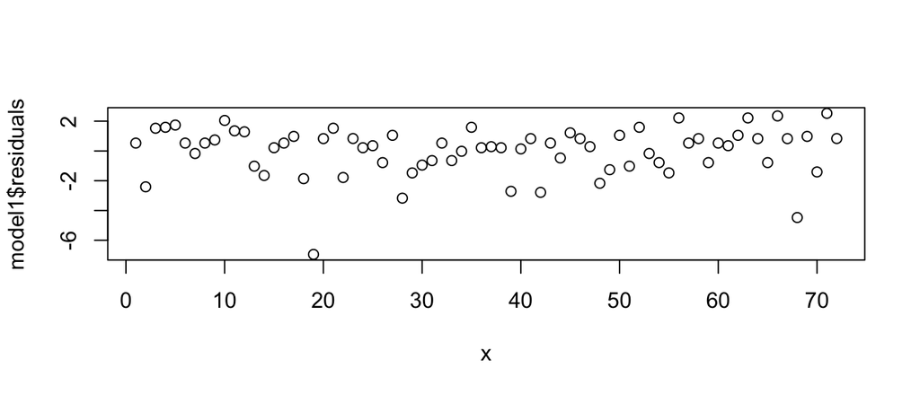

```r
x <- 1:length(model1$residuals)
plot(model1$residuals ~ x)
```

This graph shows that there does not seem to be any non-random pattern to the data, as the residuals are randomly scattered when plotted according to collection order. This assumption seems to be satisfied.

### Equality of Variances:

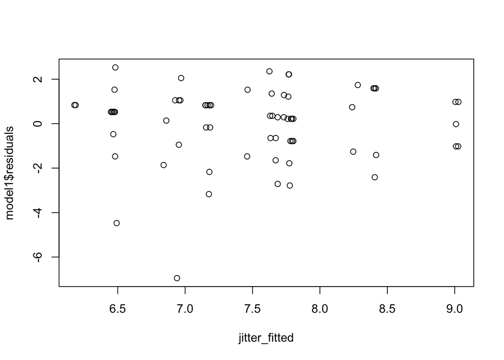

```r
jitter_fitted <- jitter(model1$fitted.values, factor = 2, amount = NULL)
plot(model1$residuals ~ jitter_fitted)
```

After jittering the data to reveal all of the data points, this graph shows that there does not seem to be any non-equal variances to the data, as the residuals are randomly scattered when plotted. There is no heteroskedasticity which would look like a cone on this graph. This assumption seems to be satisfied.

With the normality assumption of the GCBD ANOVA violated, the p-values of our statistical tests might not be accurate. We can choose to remove outliers in attempts to better fit the normality assumptions, or run a GCBD permutation test instead. Since there does not look to be a few outliers affecting the normality of the data, and rather a general pattern of non-normality, a permutation test will be used to analyze the dataset instead.

## ANOVA Permutation Test

```r
set.seed(12345) # set seed for reproducibility

perm_f <- NA   # create a vector to store the t values
reps <- 10000   # set the number of replications
for(i in 1:reps){
  df_perm <- survey_data # temporarily copy the whole df
  df_perm$Score <- sample(df_perm$Score) # randomly reorder the y values in col 1
  perm_f[i] <- summary(aov(Score ~ Treatment + Grade, data=df_perm))[[1]][1,4]
}
F_ <- summary(aov(Score ~ Treatment + Grade, data=survey_data))[[1]][1,4]
pval <- sum(perm_f >= F_)/reps


pvalkable <-
data.frame(
  pvalue = c(pval)
)

kable(pvalkable, caption = "Permutation Test p-value")
```

Permutation Test p-value

| pvalue |
| --- |
| 0.0227 |

The result of the permutation test is a p-value of 0.0227, compared to the p-value of the ANOVA test at 0.02844. Both of these values are smaller than 0.05, so we can safely stick with the original ANOVA conclusion of rejecting the null hypothesis (the mean scores of all treatment groups are the same).

## Sample Size Calculations

In order to determine the necessary sample size for this experiment, a post-hoc analysis was conducted on the collected data using a Power ANOVA Test.

### Best Case

The group means and variances were taken from the summary statistics table of the dataset.

```r
groupmeans <- summary_table$Mean
bestcase <- power.anova.test(groups=length(groupmeans),
between.var=var(groupmeans),
within.var=2.08,
power=0.8, sig.level=0.05, n=NULL)

bestcasedf <- data.frame(
  Groups = bestcase$groups,
  n = bestcase$n,
  BetweenVar = bestcase$between.var,
  WithinVar = bestcase$within.var,
  SigLevel = bestcase$sig.level,
  Power = bestcase$power)
kable(bestcasedf, caption = 'Best Case Sample Size')
```

Best Case Sample Size

| Groups | n | BetweenVar | WithinVar | SigLevel | Power |
| --- | --- | --- | --- | --- | --- |
| 3 | 23.46268 | 0.4466333 | 2.08 | 0.05 | 0.8 |

In the best case, a sample size of 24 per group is needed.

### Worst Case

```r
worstcase <- power.anova.test(groups=length(groupmeans),
between.var=var(groupmeans),
within.var=4.19,
power=0.8, sig.level=0.05, n=NULL)

worstcasedf <- data.frame(
  Groups = worstcase$groups,
  n = worstcase$n,
  BetweenVar = worstcase$between.var,
  WithinVar = worstcase$within.var,
  SigLevel = worstcase$sig.level,
  Power = worstcase$power)
kable(worstcasedf, caption = 'Worst Case Sample Size')
```

Worst Case Sample Size

| Groups | n | BetweenVar | WithinVar | SigLevel | Power |
| --- | --- | --- | --- | --- | --- |
| 3 | 46.20629 | 0.4466333 | 4.19 | 0.05 | 0.8 |

In the worst case, a sample size of 47 per group is needed.

To assess over a large range of Between-Group and Within-Group variances, a graph was made.

```r
bgvar <- round(var(c(7.54,6.76,8.09)), 3)
```

The Within-Group variances had values of 2.61, 4.19, and 2.08. The Between-Group variance was calculated using the means of each treatment group and had a value of 0.447.

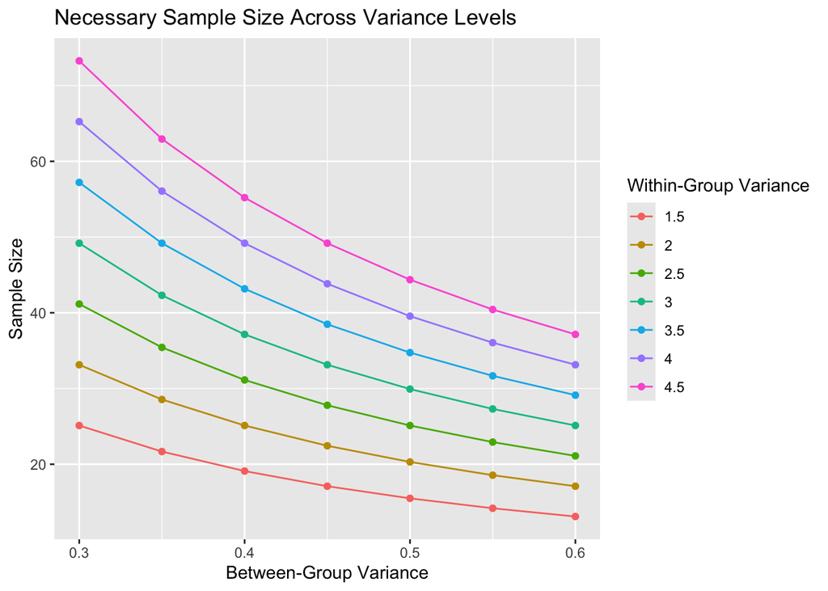

```r
between.var <- seq(.3, .6, by=.05)
within.var <- c(1.5, 2, 2.5, 3, 3.5, 4, 4.5)

power_results <- data.frame()

for (l in within.var) {
  for (i in between.var) {
    result <- power.anova.test(groups = 3,
                       between.var = i,
                       within.var = l,
                       power = 0.8,
                       sig.level = 0.05)
    power_results <- rbind(power_results, data.frame(BetweenVar = i,
                                        WithinVar = l, SampleSize = result$n))
  }
}

ggplot(power_results, aes(x = BetweenVar, y = SampleSize,
                          color = factor(WithinVar))) +
  geom_line(linewidth = .5) + geom_point() +
  labs(x = "Between-Group Variance",
       y = "Sample Size",
       title = 'Necessary Sample Size Across Variance Levels',
       color = "Within-Group Variance")
```

From the values obtained from the data, the dataset sample size of 23-25 observations per treatment group seems to be just under or right at the sample size needed in the best case scenario. In this experiment, slightly more data would be better to confidently say that the observed difference in scores across treatment groups was actually due to the treatments.

# Discussion

According to this experiment, the wording of a question has an impact on how concerned a student is about a local environmental topic. A generalized complete block design experiment ANOVA test and permutation test was used to compare the means of the 3 treatment groups, with alternate wordings on the same local environmental issue.

Treatment groups:

1. I am worried about cliff erosion in Isla Vista.
2. I am worried about houses and decks on DP falling into the ocean.
3. I am worried about climate change and cliff erosion causing houses and decks on DP to fall into the ocean.

Both p-values of 0.02844 (ANOVA) and 0.0227 (Permutation) were less than $\alpha$ = 0.05 and thus small enough to reject the null hypothesis, supporting that the means of the three groups were different. Blocking of grade levels did not look to be statistically significant in this experiment. According to Tukey’s test, Treatment groups 2 and 3 had a statistically significant difference in means, while the other pairs did not.

This was an interesting result, since Treatment 2 had the lowest level of concern and Treatment 3 had the highest. The cause and effect nature of Treatment 3 incorporating both climate change, physical processes and personal/property safety seemed to result in the highest level of concern, while people were less worried about purely property damage and possible injury. This may be because Treatment 2 did not mention any reason decks or houses would fall into the ocean, and those not fully aware of the issue may not have thought of a plausible reason to worry about that scenario. Similarly for Treatment 1, participants were told about cliff erosion but not a specific reason why they might need to worry about it. Treatment 3 laid out a plausible chain of events that may have been easier to picture and worry about. However, the actual reason for the difference in mean scores is unknown and could be further tested in the future.

Since we performed a parametric statistical test, we assume that the samples are random samples of the target population. Due to the specific topic of the question being relevant to the local community, the target population would be students at UCSB. The collected data may not be fully representative of the target audience for a variety of reasons. First is the number of responses from each grade, as mentioned previously in the Methods section. Most of the participants were 3rd years due to the method of survey distribution. Although this experiment did not find statistical significance due to blocking, it is reasonable to believe that as students spend more time at UCSB, they may become more aware of local issues. In the interaction plot, 4th years were the most worried about the issue acorss all treatment groups. An additional factor is that the Instagram account used for distribution belonged to an Earth science major with involvement in environmental organizations and connections to various environmental science majors. Thus it is possible that the survey participants had a higher than average awareness for local environmental issues than the general UCSB student population.

The sample size for this experiment was also not quite large enough to guarantee that the concluding results were for sure due to a difference in means across treatment groups, or if they were from random variability. This study would be more accurate if a larger sample size was used and the survey was distributed more widely, across different grades and majors.

The results of this study seem to support the idea that subtle changes in wording and framing have an impact on opinions, especially on sensitive issues such as environmental ones. This supports Schuldt, J. P., Konrath, S. H., & Schwarz, N. (2011) and may have implications on getting students to care about local issues. As a school located near the ocean and many at-risk habitats, environmental issues are a core part of the UCSB community. While other college campuses may not see similar results in regards to environmental topics, the idea of question-wording bias can be applied to many other social or political issues local to a given population.

# References

Cantril, H. (1944). Gauging public opinion. Princeton University Press.

Schuldt, J. P., Konrath, S. H., & Schwarz, N. (2011). ‘‘Global warming’’ or ‘‘climate change’’? Whether the planet is warming depends on question wording. Public Opinion Quarterly, 75(1), 115–124. https://doi.org/10.1093/poq/nfq073

Tourangeau, R., & Yan, T. (2007). Sensitive questions in surveys. Psychological Bulletin, 133(5), 859–883. https://doi.org/10.1037/0033-2909.133.5.859